# Home-work 1, data 608, Fall 2018

Mehdi M Khan

**Principles of Data Visualization and Introduction to ggplot2**

data about the 5,000 fastest growing companies in the US, as compiled by Inc. magazine.

#### load the data:

```r
inc <- read.csv("https://raw.githubusercontent.com/kmehdi2017/data608/master/hw_module1/Data/inc5000_data.csv", header= TRUE)
```

#### preview data:

```r
head(inc)
```

|  | Rank | Name | Growth_Rate | Revenue | Industry | Employees | City | State |
| --- | --- | --- | --- | --- | --- | --- | --- | --- |
| 1 | 1 | Fuhu | 421.48 | 117900000 | Consumer Products & Services | 104 | El Segundo | CA |
| 2 | 2 | FederalConference.com | 248.31 | 49600000 | Government Services | 51 | Dumfries | VA |
| 3 | 3 | The HCI Group | 245.45 | 25500000 | Health | 132 | Jacksonville | FL |
| 4 | 4 | Bridger | 233.08 | 1900000000 | Energy | 50 | Addison | TX |
| 5 | 5 | DataXu | 213.37 | 87000000 | Advertising & Marketing | 220 | Boston | MA |
| 6 | 6 | MileStone Community Builders | 179.38 | 45700000 | Real Estate | 63 | Austin | TX |

#### descriptive statistics:

```r
summary(inc)
```

```
      Rank                          Name       Growth_Rate         Revenue                                    Industry
 Min.   :   1   (Add)ventures         :   1   Min.   :  0.340   Min.   :    2000000   IT Services                 : 733
 1st Qu.:1252   @Properties           :   1   1st Qu.:  0.770   1st Qu.:    5100000   Business Products & Services: 482
 Median :2502   1-Stop Translation USA:   1   Median :  1.420   Median :   10900000   Advertising & Marketing     : 471
 Mean   :2502   110 Consulting        :   1   Mean   :  4.612   Mean   :   48222535   Health                      : 355
 3rd Qu.:3751   11thStreetCoffee.com  :   1   3rd Qu.:  3.290   3rd Qu.:   28600000   Software                    : 342
 Max.   :5000   123 Exteriors         :   1   Max.   :421.480   Max.   :10100000000   Financial Services          : 260
                (Other)               :4995                                           (Other)                     :2358
   Employees                  City          State
 Min.   :    1.0   New York     : 160   CA     : 701
 1st Qu.:   25.0   Chicago      :  90   TX     : 387
 Median :   53.0   Austin       :  88   NY     : 311
 Mean   :  232.7   Houston      :  76   VA     : 283
 3rd Qu.:  132.0   San Francisco:  75   FL     : 282
 Max.   :66803.0   Atlanta      :  74   IL     : 273
 NA's   :12        (Other)      :4438   (Other):2764
```

#### some more relevant non-visual exploratory information about the data:

```r
# Insert your code here, create more chunks as necessary
options(scipen=999) # to avoid scientific notations
# Getting more descriptive statistics of the data
suppressWarnings(suppressMessages(library(psych)))
describe(inc)
```

```
inc

 8  Variables      5001  Observations
------------------------------------------------------------------------------------------------------------------------------------------
Rank
       n  missing distinct     Info     Mean      Gmd      .05      .10      .25      .50      .75      .90      .95
    5001        0     4999        1     2502     1667      252      502     1252     2502     3751     4501     4751

lowest :    1    2    3    4    5, highest: 4996 4997 4998 4999 5000
------------------------------------------------------------------------------------------------------------------------------------------
Name
       n  missing distinct
    5001        0     5001

lowest : (Add)ventures                          @Properties                            1-Stop Translation USA                 110 Consulting                         11thStreetCoffee.com
highest: Zoup!                                  ZT Wealth and Altus Group of Companies Zumasys                                Zurple                                 ZweigWhite
------------------------------------------------------------------------------------------------------------------------------------------
Growth_Rate
       n  missing distinct     Info     Mean      Gmd      .05      .10      .25      .50      .75      .90      .95
    5001        0     1147        1    4.612    6.493     0.43     0.50     0.77     1.42     3.29     9.12    17.16

lowest :   0.34   0.35   0.36   0.37   0.38, highest: 213.37 233.08 245.45 248.31 421.48
------------------------------------------------------------------------------------------------------------------------------------------
Revenue
        n   missing  distinct      Info      Mean       Gmd       .05       .10       .25       .50       .75       .90       .95
     5001         0      1069         1  48222535  75111227   2400000   3000000   5100000  10900000  28600000  76900000 155600000

lowest :     2000000     2100000     2200000     2300000     2400000, highest:  3800000000  4500000000  4600000000  4700000000 10100000000
------------------------------------------------------------------------------------------------------------------------------------------
Industry
       n  missing distinct
    5001        0       25

lowest : Advertising & Marketing      Business Products & Services Computer Hardware            Construction                 Consumer Products & Services
highest: Retail                       Security                     Software                     Telecommunications           Travel & Hospitality
------------------------------------------------------------------------------------------------------------------------------------------
Employees
       n  missing distinct     Info     Mean      Gmd      .05      .10      .25      .50      .75      .90      .95
    4989       12      691        1    232.7    365.6     10.0     14.0     25.0     53.0    132.0    351.2    688.0

lowest :     1     2     3     4     5, highest: 17057 18887 20000 32000 66803
------------------------------------------------------------------------------------------------------------------------------------------
City
       n  missing distinct
    5001        0     1519

lowest : Acton        Addison      Adrian       Agoura Hills Aiea        , highest: Worthington  Wyomissing   Yonkers      Youngsville  Zumbrota
------------------------------------------------------------------------------------------------------------------------------------------
State
       n  missing distinct
    5001        0       52

lowest : AK AL AR AZ CA, highest: VT WA WI WV WY
------------------------------------------------------------------------------------------------------------------------------------------
```

```r
# information about data types, zeros,  missing values, unique values
suppressWarnings(suppressMessages(library(funModeling)))
df_status(inc)
```

| variable | q_zeros | p_zeros | q_na | p_na | q_inf | p_inf | type | unique |
| --- | --- | --- | --- | --- | --- | --- | --- | --- |
| Rank | 0 | 0 | 0 | 0.00 | 0 | 0 | integer | 4999 |
| Name | 0 | 0 | 0 | 0.00 | 0 | 0 | factor | 5001 |
| Growth_Rate | 0 | 0 | 0 | 0.00 | 0 | 0 | numeric | 1147 |
| Revenue | 0 | 0 | 0 | 0.00 | 0 | 0 | numeric | 1069 |
| Industry | 0 | 0 | 0 | 0.00 | 0 | 0 | factor | 25 |
| Employees | 0 | 0 | 12 | 0.24 | 0 | 0 | integer | 691 |
| City | 0 | 0 | 0 | 0.00 | 0 | 0 | factor | 1519 |
| State | 0 | 0 | 0 | 0.00 | 0 | 0 | factor | 52 |

## Question 1

Create a graph that shows the distribution of companies in the dataset by State (ie how many are in each state). There are a lot of States, so consider which axis you should use. This visualization is ultimately going to be consumed on a ‘portrait’ oriented screen (ie taller than wide), which should further guide your layout choices.

```r
# load libraries
suppressMessages(suppressWarnings(library(ggplot2)))
suppressMessages(suppressWarnings(library(dplyr)))
suppressMessages(suppressWarnings(library(plyr)))
suppressMessages(suppressWarnings(library(grid)))
```

### Answer (plot 1)

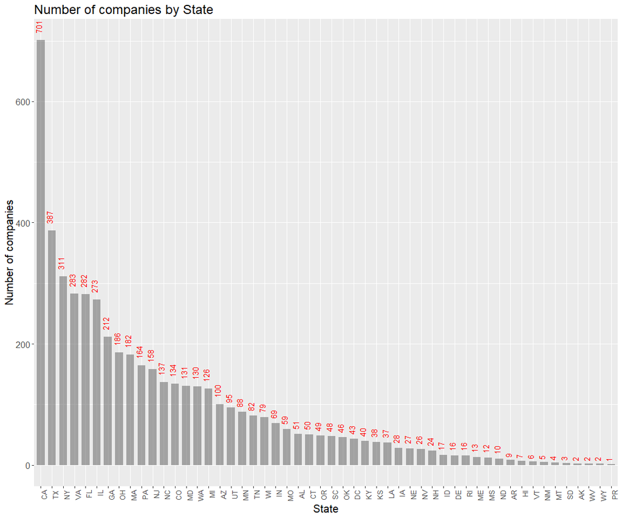

```r
inc_state <- ddply(inc,"State",summarise, "company_count"=length(Name))
p <- ggplot(inc_state,aes(x=reorder(State,-company_count),y=company_count))
p <- p + geom_bar(stat = "identity", alpha=.5, width=0.7)
p <- p + labs(title = "Number of companies by State", x= "State",y = "Number of companies")
p <- p + theme(plot.title = element_text(size=18),
               axis.text.x = element_text(angle=90, hjust = 1, size = 10 ),
               axis.text.y = element_text(size = 12 ),
               axis.title.x = element_text(size = 15 ),
               axis.title.y = element_text(size = 15 ))
p <- p + geom_text( aes(label=company_count),vjust=.10, angle=90, hjust=-.5, col="red", size=4)
p
```

## Quesiton 2

Lets dig in on the state with the 3rd most companies in the data set. Imagine you work for the state and are interested in how many people are employed by companies in different industries. Create a plot that shows the average and/or median employment by industry for companies in this state (only use cases with full data, use R’s `complete.cases()` function.) In addition to this, your graph should show how variable the ranges are, and you should deal with outliers.

### answer (Plot 2)

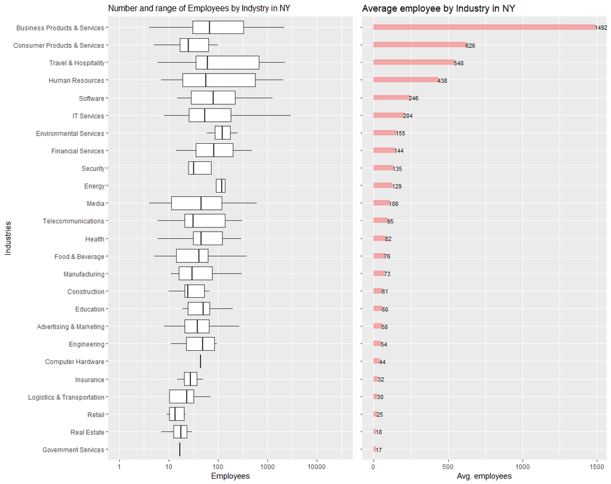

```r
# Answer Question 2 here
# The above plot (plot 1) shows 'NY' is with the 3rd most companies in the data set
inc2 <- inc[complete.cases(inc),]
inc2 <- inc2[which (inc2$State =='NY'),]

p1 <- ggplot(inc2,aes(reorder(Industry,Employees,mean),Employees))  + geom_boxplot(outlier.shape = NA, show.legend=F)+ labs(title="Number and range of Employees by Indystry in NY",x="Industries") + coord_flip() +
    scale_y_continuous(
        trans = "log10"
    ) + theme(plot.title = element_text(size = 12) )
mean_fun <- function(x){
  return(data.frame(y = mean(x), label = paste0("mean = ",round(mean(x),1))))
}
p2 <- ggplot(inc2, aes(reorder(Industry,Employees,mean),Employees) )+ stat_summary(fun.y = mean,geom = "bar", width=.3,fill="red", alpha=.3) + stat_summary(aes(label=round(..y..,0)),fun.y = mean,geom = "text", size=3, hjust=.1 ) + coord_flip()+labs(title="Average employee by Industry in NY", y="Avg. employees")+theme(axis.text.y=element_blank(),axis.title.y=element_blank())
grid.newpage()
grid.draw(cbind(ggplotGrob(p1),ggplotGrob(p2),size="last"))
```

## Question 3

Now imagine you work for an investor and want to see which industries generate the most revenue per employee. Create a chart that makes this information clear. Once again, the distribution per industry should be shown.

### Answer (plot 3)

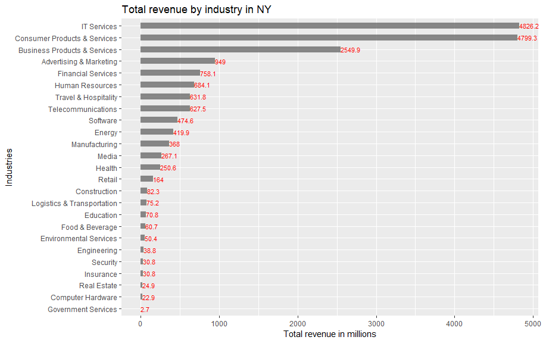

```r
# Answer Question 3 here
emp_rev <- ddply(inc2,"Industry",summarise,"Total_revenue" = sum(Revenue))
ggplot(emp_rev,aes(reorder(Industry,Total_revenue),Total_revenue/1000000))+geom_bar(stat = "identity", width = .5, alpha=.7)+coord_flip() + geom_text(aes(label=Total_revenue/1000000), size=3, colour="red",hjust=0) + labs(title="Total revenue by industry in NY", x= "Industries", y = "Total revenue in millions")
```